# Novel Relationships Between Temperature, Kelp Abundance, and Species Richness in New England Kelp Forests

Jarrett E. K. Byrnes, Alison Haupt, Jennifer A. Dijkstra, Jonathan Grabowski, Marissa McMahan, Douglas Rasher, Austin T. Humphries

#### Introduction

I. Key to understand direct and indirect effects of climate change  
A. Particularly important wrt foundation species  
II. Kelp forest paradigm is envt -> kelp -> community  
A. Some direct envt effect, but variable  
III. New England kelp morphology very different, different ecology  
A. Levin et al indications that kelp is not only foundation species here  
B. Look at Ecklonia systems C. Look, we’re New England. Whatever, California.  
D. Transition with talking about sugar kelp as dominant IV. Sugar kelp is sensitive to temperature via multiple mechanisms  
A. Temp up, kelp should go down from expts  
B. Review everything from Gerard to killer Nova Scotia work  
V. But does it blend in the field?  
A. To answer if temp drives kelp and community, we put together large-scale survey  
B. KEEN intro, and how it will answer questions.  
C. Leave the reader wanting more by saying we show that our system is totes different

#### Methods

##### Temperature

We collected temperature from the nearest offshore buoy to each site. While these temperatures were likely not the conditions experienced precisely at the site, they should at least correlate to both regional and temporal trends experienced by kelps. As kelp reproduction and initial growth occurs in the winter and early spring, we chose to examine minimum winter temperature as a reflection of conditions that could influence both kelp abundance as well as influence the community as a whole. **note to self - this justification either needs beefing up, referencing - ha, or I need to systematically test a few other summarizations of temperature. They’re all pretty correlated anyway** –**Note to co-authors, I also attempted this briefly with nearest NOAA monitoring station, as this pulled stations within the Narraganset and Boston Harbor, but those stations differed by upwards of 8C on minima from others, and not in directions you would suspect, leading me to think that offshore is the more appropriate way to go**

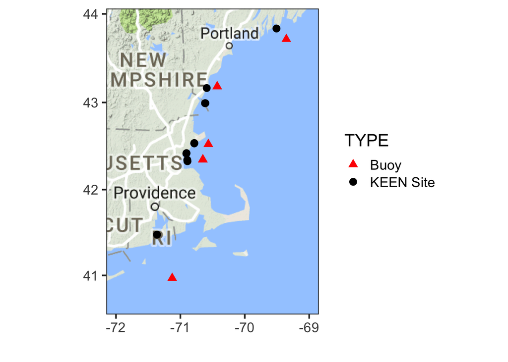

While some sites had benthic loggers deployed during the period of observation, buoy data enabled a more comprehensive analysis for two reasons. First, this meant that the first year sampled had to be thrown out due to no preceeding winter temperatures recorded. This filtering was particularly problematic as a few sites only have one year of data at present. Second, For analyses to determine a proper causal linkage (see data analysis below), we required temperature data during the duration of sampling for the entire data set - e.g., even for a site sampled in 2016, our models required data from 2013-2017.

##### Statistical analysis (currently interdigitated with results for the whole data set)

To examine the relationship between temperature and *Saccharina latissima* abundance, we first took a naive look at the relationship between winter minimum temperature at kelp abundance by fitting a generalized linear mixed model with a lognormal error and log link. Percent rocky substrate was included as a covariate, and we included a random effect of site. To evaluate the model, we include a chi square log ratio test of the model as well as tests of the coefficients.

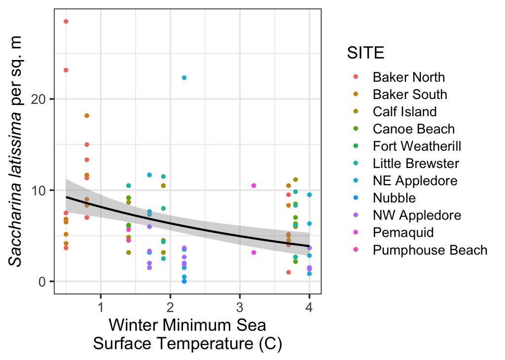

|  | Chisq | Df | Pr(>Chisq) |
| --- | --- | --- | --- |
| WINTER_MIN_SEA_SURFACE_TEMPERATURE | 7.497 | 1 | 0.006 |
| PERCENT_ROCK | 1.055 | 1 | 0.304 |

| effect | group | term | estimate | std.error | statistic | p.value |
| --- | --- | --- | --- | --- | --- | --- |
| fixed | fixed | (Intercept) | 1.644 | 0.708 | 2.323 | 0.020 |
| fixed | fixed | WINTER_MIN_SEA_SURFACE_TEMPERATURE | -0.146 | 0.053 | -2.738 | 0.006 |
| fixed | fixed | PERCENT_ROCK | 0.004 | 0.004 | 1.027 | 0.304 |
| ran_pars | SITE | sd_(Intercept) | 1.914 | NA | NA | NA |
| ran_pars | Residual | sd_Observation | 3.851 | NA | NA | NA |

While this model seems to demonstrate a negative relationship between temperature and sugar kelp abundance, given spatial gradients of temperature that correlate with a wide variety of other drivers, it’s difficult to say whether this represents a true relationship. To assess the importance of temperature with greater confidence, we used a hierarchical model with group mean centering [@REF TBA]. By calculating a centered mean temperature from 2014-2016, an annual deviation from site-level mean, and including both in the model along with a random effect of site, we’re able to 1) derive a relationship driven by between-year variation in temperature without the confusion of spatial correlates and 2) evaluate the relationship due to spatial differences in thermal regime via use of a hierarchical predictor alongside a site-level random effect. In essence, we partition the spatial and temporal component of temperature’s effects, and the deviation from site average coefficient addresses the impact of temporal change in temperature at a site.

|  | Chisq | Df | Pr(>Chisq) |
| --- | --- | --- | --- |
| group_temp | 0.875 | 1 | 0.350 |
| temp_group_cent | 7.370 | 1 | 0.007 |
| PERCENT_ROCK | 1.076 | 1 | 0.300 |

| effect | group | term | estimate | std.error | statistic | p.value |
| --- | --- | --- | --- | --- | --- | --- |
| fixed | fixed | (Intercept) | 3.962 | 2.832 | 1.399 | 0.162 |
| fixed | fixed | group_temp | -1.144 | 1.223 | -0.935 | 0.350 |
| fixed | fixed | temp_group_cent | -0.144 | 0.053 | -2.715 | 0.007 |
| fixed | fixed | PERCENT_ROCK | 0.004 | 0.004 | 1.037 | 0.300 |
| ran_pars | SITE | sd_(Intercept) | 1.270 | NA | NA | NA |
| ran_pars | Residual | sd_Observation | 3.856 | NA | NA | NA |

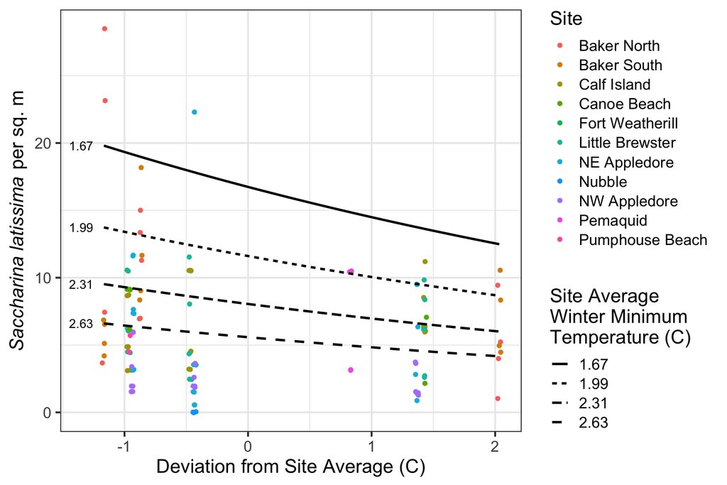

This model shows a roughly 13.4% decrease in kelp per degree increase in temperature at a site.

|  | Chisq | Df | Pr(>Chisq) |
| --- | --- | --- | --- |
| TEMP_DIFF | 20.220 | 1 | 0.000 |
| SITE_PERCENT_ROCK | 9.081 | 1 | 0.003 |

| effect | group | term | estimate | std.error | df | statistic | p.value |
| --- | --- | --- | --- | --- | --- | --- | --- |
| fixed | fixed | (Intercept) | -183.940 | 72.071 | 5 | -2.552 | 0.051 |
| fixed | fixed | TEMP_DIFF | -21.613 | 4.806 | 4 | -4.497 | 0.011 |
| fixed | fixed | SITE_PERCENT_ROCK | 2.545 | 0.844 | 4 | 3.014 | 0.039 |
| ran_pars | SITE | sd_(Intercept) | 48.235 | NA | NA | NA | NA |
| ran_pars | Residual | sd_Observation | 22.731 | NA | NA | NA | NA |

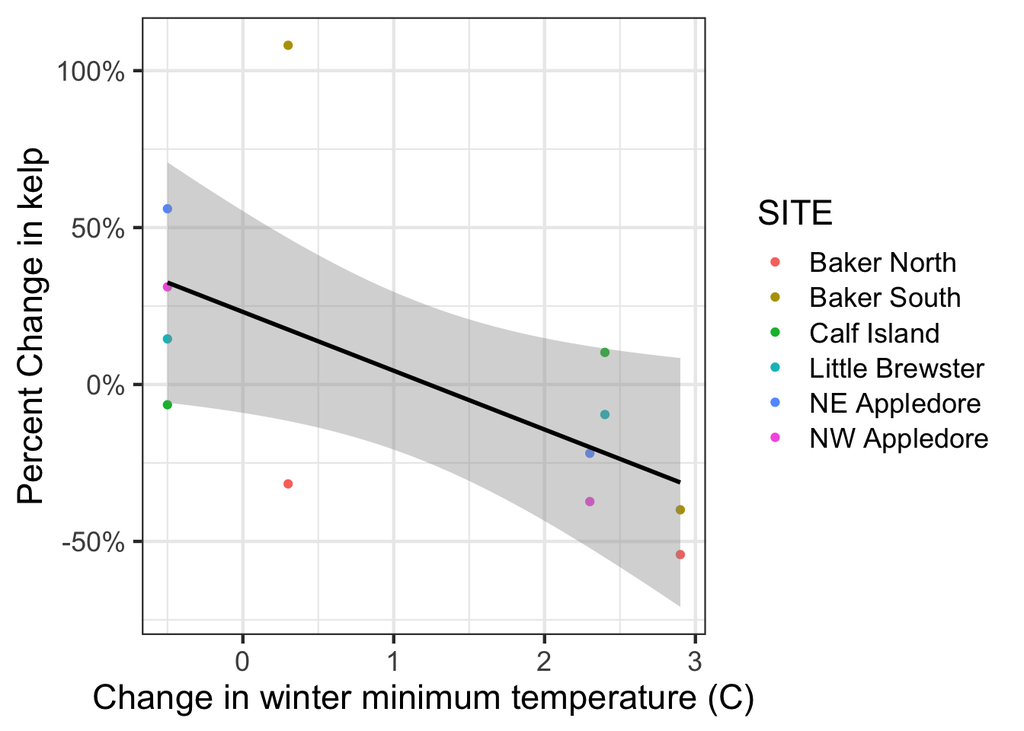